# Measuring the Z boson mass

Let's look at a sample of $Z$ boson candidates recorded by CMS in 2011 and published at CERN opendata portal. It comes from DoubleMuon dataset with the following selection applied:

- Both muons are "global" muons
- invariant mass sits in range: 60 GeV < $M_{\mu\mu}$ < 120 GeV
- |$\eta$| < 2.1 for both muons
- $p_{t}$ > 20 GeV

The following columns presented in the CSV file:

- `Run`, `Event` are the run and event numbers, respectively
- `pt` is the transverse momentum $p_{t}$ of the muon
- `eta` is the pseudorapidity of the muon: $\eta$
- `phi` is the $\phi$ angle of the muon direction
- `Q` is the charge of the muon
- `dxy` is the impact parameter in the transverse plane: $d_{xy}$ - how distant is the track from the collision point
- `iso` is the track isolation: $I_{track}$ - how many other tracks are there around given track

```python
import numpy as np
import pandas as pd
import matplotlib.pyplot as plt
from skopt import gp_minimize
%matplotlib inline
```

## Reading the dataset

```python
df = pd.read_csv('./Zmumu.csv')
df.shape
```

```
(10000, 14)
```

Calculating the invariant mass $M$ of the two muons using the formula

$M = \sqrt{2p_{t}^{1}p_{t}^{2}(\cosh(\eta_{1}-\eta_{2}) - \cos(\phi_{1}-\phi_{2}))}$

```python
df['M'] = np.sqrt(2 * df['pt1'] * df['pt2'] * (np.cosh(df['eta1'] - df['eta2']) - np.cos(df['phi1'] - df['phi2'])))
df.head()
```

|  | Run | Event | pt1 | eta1 | phi1 | Q1 | dxy1 | iso1 | pt2 | eta2 | phi2 | Q2 | dxy2 | iso2 | M |
| --- | --- | --- | --- | --- | --- | --- | --- | --- | --- | --- | --- | --- | --- | --- | --- |
| 0 | 165617 | 74969122 | 54.7055 | -0.4324 | 2.5742 | 1 | -0.0745 | 0.4999 | 34.2464 | -0.9885 | -0.4987 | -1 | 0.0712 | 3.4221 | 89.885919 |
| 1 | 165617 | 75138253 | 24.5872 | -2.0522 | 2.8666 | -1 | -0.0554 | 0.0000 | 28.5389 | 0.3852 | -1.9912 | 1 | 0.0515 | 0.0000 | 88.812177 |
| 2 | 165617 | 75887636 | 31.7386 | -2.2595 | -1.3323 | -1 | 0.0879 | 0.0000 | 30.2344 | -0.4684 | 1.8833 | 1 | -0.0876 | 0.0000 | 88.474683 |
| 3 | 165617 | 75779415 | 39.7394 | -0.7123 | -0.3123 | 1 | 0.0585 | 0.0000 | 48.2790 | -0.1956 | 2.9703 | -1 | -0.0492 | 0.0000 | 90.332429 |
| 4 | 165617 | 75098104 | 41.2998 | -0.1571 | -3.0408 | 1 | -0.0305 | 1.2280 | 43.4508 | 0.5910 | -0.0428 | -1 | 0.0442 | 0.0000 | 90.515882 |

# Model

The distribution of the Z boson mass has the form of a normal distribution, in addition there is a noise. The distribution of the noise has an exponential form. Thus, the resulting model, it is a result of a superposition of two distributions - normal and polinomial

Plotting the distribution of Z boson mass

```python
def plot_mass(mass, bins_count=200):
    y, x = np.histogram(mass, bins=bins_count, density=False)
    err = np.sqrt(y)

    fig = plt.figure(figsize=(15,7))
    plt.title('Z mass', fontsize=20)
    plt.xlabel("$m_{\mu\mu}$ [GeV]", fontsize=20)
    plt.ylabel("Number of events", fontsize=20)
    plt.errorbar(x[:-1], y, yerr=err, fmt='o', color='red', ecolor='grey', capthick=0.5, zorder=1, label="data")
    return y, x
```

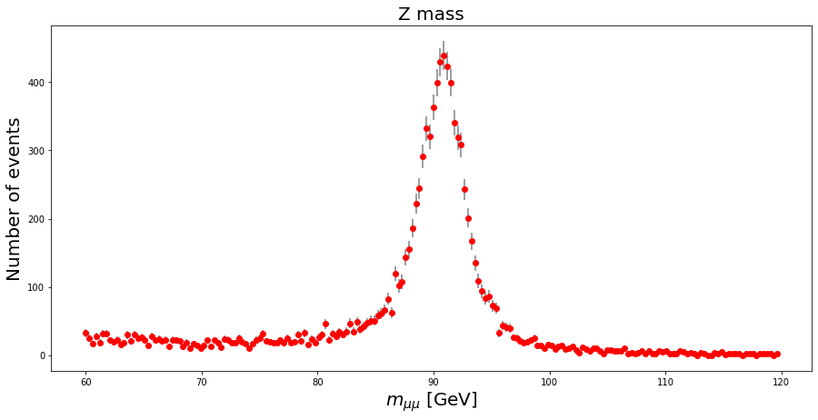

```python
plot_mass(df.M);
```

## Cleaning up the dataset a bit

- charge of muons should be opposite
- $I_{track}$ < 3 and $d_{xy}$ < 0.2 cm

```python
### YOUR CODE GOES HERE ###
df_sign = df[((df.Q1 > 0) & (df.Q2 < 0)) | ((df.Q1 < 0) & (df.Q2 > 0))]
df_isolation = df_sign[(df_sign.iso1 < 3) & (df_sign.iso2 < 3) & (df_sign.dxy1.abs() < 0.2) & (df_sign.dxy2.abs() < 0.2)]
df = df_isolation
```

```python
df.shape
```

```
(8818, 15)
```

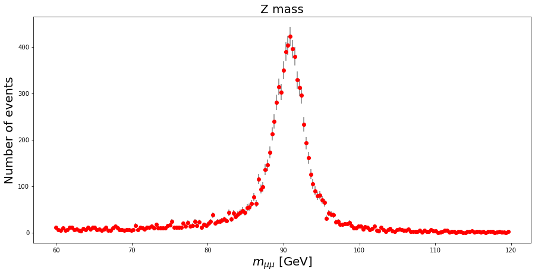

```python
plot_mass(df.M);
```

### Defining a parametrised model

it represents a mixture of 1) Gaussian signal and 2) background . So the following set of parameters will be used:

- m0 - center of the Gaussian
- sigma - standard deviation of the Gaussian
- ampl - height of the peak
- bck - height of the background

```python
def model_predict(params, X):
    m0, sigma, ampl, bck = params
    return np.exp(-bck) + ampl / (sigma * np.sqrt(2 * np.pi)) * np.exp((-1/2) * (X - m0)**2 / (sigma**2))
```

```python
def model_loss(params, X, y):
    residuals = y - model_predict(params, X)
    return np.sqrt(np.sum(residuals**2)) / len(residuals)
```

```python
def plot_mass_with_model(params, mass, bins_count=100):
    y, X = plot_mass(mass, bins_count=bins_count)
    X = (X[1:] + X[:-1]) / 2
    error = model_loss(params, X, y)
    plt.plot(X, model_predict(params, X), color='blue', linewidth=3.0, zorder=2, label="fit, loss=%.2f" % error)
    plt.legend(fontsize='x-large')
```

## We can fit model parameters by hand

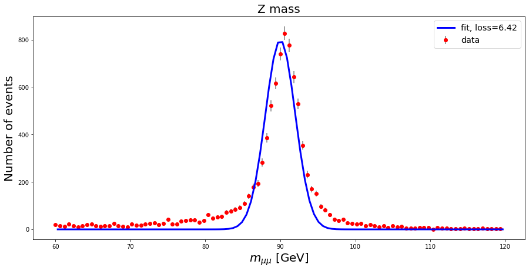

```python
plot_mass_with_model((90, 2, 4000, 10), df.M)
```

## ... but we will do it automatically

To get a sense of how actually it can be calculated using experimental data

Setting up a scikit optimizer

```python
from tqdm import tqdm
from skopt import Optimizer

search_space = [(60.0, 120.0), # m0 range
    (0.5, 10.0), # sigma range
    (0, 10000), # amplitude range
    (0, 80) # bck range
    ]

y, X = np.histogram(df.M, bins=100, density=False)
X = (X[1:] + X[:-1]) / 2
opt = Optimizer(search_space, base_estimator="GP", acq_func="EI", acq_optimizer="lbfgs")
```

```python
from skopt.utils import create_result
for i in tqdm(range(100)):
    next_x = opt.ask()
    f_val = model_loss(next_x, X, y)
    opt.tell(next_x, f_val)

res = create_result(Xi=opt.Xi, yi=opt.yi, space=opt.space,
                         rng=opt.rng, models=opt.models)
```

## A bit of search history

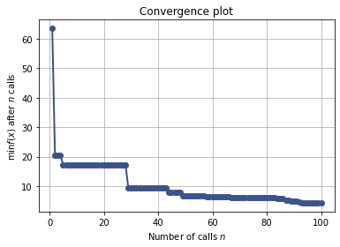

```python
import skopt.plots
skopt.plots.plot_convergence(res)
```

```python
print (list(zip(["m0", "sigma", "ampl", "bck"], res.x)))
```

```
[('m0', 91.08930828005937), ('sigma', 2.7493193708327284), ('ampl', 4678), ('bck', 0)]
```

Let's see how well the prediction fits the data

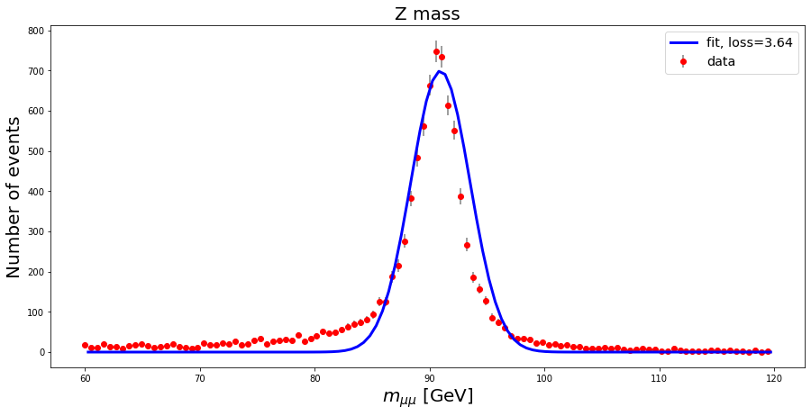

```python
plot_mass_with_model(res.x, df.M, bins_count=110)
```

### Hence, the mass of Z Boson, as calculated using the above method is 91.089308280059 ± 2.74931937083272 which is well within the acceptable range